# Inference for Categorical Data

## Millennials and Marriage

In the national debate on same-sex marriage, it is commonly stated that half of all americans favor same-sex marriage. In 2014, Pew research conducted a poll of millennials (americans born after 1980) and found that 66% answered yes when asked: “Do you favor same-sex marriage?” The poll was a random sample of 75 millennials. Does this poll provide convincing evidence that the opinion of millennials is different from those of americans at large?

```r
head(millenials)
```

```
##   id     response
## 1  1 do not favor
## 2  2 do not favor
## 3  3 do not favor
## 4  4        favor
## 5  5 do not favor
## 6  6        favor
```

## Bootstrapping p-hat I

```r
millenials %>%
  specify(response = response) %>%
  generate(reps = 100, type = "bootstrap")
```

```
## # A tibble: 7,500 x 2
## # Groups:   replicate [100]
##    replicate     response
##        <int>       <fctr>
##  1         1        favor
##  2         1        favor
##  3         1        favor
##  4         1        favor
##  5         1 do not favor
##  6         1        favor
##  7         1 do not favor
##  8         1 do not favor
##  9         1 do not favor
## 10         1        favor
## # ... with 7,490 more rows
```

## Bootstrapping p-hat II

```r
millenials %>%
  specify(response = response) %>%
  generate(reps = 100, type = "bootstrap") %>%
  calculate(stat = "prop", success = "favor")
```

```
## # A tibble: 100 x 2
##    replicate  stat
##        <int> <dbl>
##  1         1 0.693
##  2         2 0.747
##  3         3 0.667
##  4         4 0.627
##  5         5 0.693
##  6         6 0.640
##  7         7 0.640
##  8         8 0.707
##  9         9 0.707
## 10        10 0.573
## # ... with 90 more rows
```

## Bootstrapping p-hat III

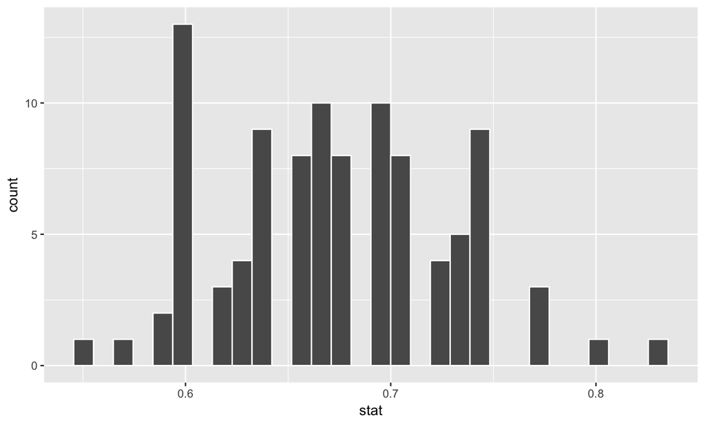

```r
millenials %>%
  specify(response = response) %>%
  generate(reps = 100, type = "bootstrap") %>%
  calculate(stat = "prop", success = "favor") %>%
  visualize()
```

## Bootstrapping p-hat III

```r
boot_se <- millenials %>%
  specify(response = response) %>%
  generate(reps = 100, type = "bootstrap") %>%
  calculate(stat = "prop", success = "favor") %>%
  summarize(se = sd(stat)) %>%
  as.numeric()
boot_se
```

```
## [1] 0.0572
```

## Constructing a CI

\[ \hat{p} \pm 1.96 \times SE \]

```r
p_hat <- millenials %>%
  summarize(p = mean(response == "favor")) %>%
  as.numeric()
c(p_hat - 1.96 * boot_se, p_hat + 1.96 * boot_se)
```

```
## [1] 0.555 0.779
```

\[ .67 \pm 1.96 \times .057\]

## Normal Approximation Method

## Checking Conditions

\(\hat{p} \sim N(\mu = p, \sigma = \sqrt{\frac{p(1-p)}{n}})\) if

1. Observations are independent
2. The number of observed successes and failures is more than 10.

\[ n\hat{p} \ge 10 \\ n(1 - \hat{p}) \ge 10 \]

## Question

We are given that \(n = 75, \hat{p} = 0.67\). Which of the below is the correct calculation of the 95% confidence interval?

1. \(0.67 \pm 1.96 \sqrt{(.67 \times 0.33)/75}\)
2. \(0.67 \pm 1.65 \sqrt{(.67 \times 0.33)/75}\)
3. \(0.67 \pm 1.96 ((.67 \times 0.33)/\sqrt{75})\)
4. \(67 \pm 1.96 \sqrt{(67 \times 33)/75}\)

## Constructing a CI

```r
nrow(millenials) * p_hat
```

```
## [1] 50
```

```r
nrow(millenials) * (1 - p_hat)
```

```
## [1] 25
```

```r
SE <- sqrt((p_hat * (1 - p_hat)) / nrow(millenials))
z_star <- qnorm(.025) # for a 95% CI
z_star
```

```
## [1] -1.96
```

```r
MoE <- z_star * SE
c(p_hat - MoE, p_hat + MoE)
```

```
## [1] 0.773 0.560
```

## Choosing between methods

### Bootstrap SE

- Must have sufficiently large sample (n > 30)
- Can be calculated for any statistic

### Normal approximation

- Must satisfy assumptions (independence, sample size)
- Most commonly used (still)

## Interpreting a confidence interval

## Making decisions with confidence intervals

## A reasonable claim?

*A full 10% of Americans are atheist.*

### Claim

\(p = 0.10\)

### 95% CI

\((0.0364 , 0.0634)\)

The claim is *inconsistent* with our estimate of \(p\).

## Extending to two proportions

## Question

Scientists predict that global warming may have big effects on the polar regions within the next 100 years. One of the possible effects is that the northern ice cap may completely melt. Would this bother you a great deal, some, a little, or not at all if it actually happened?

1. A great deal
2. Some
3. A little
4. Not at all

*Are Reed Students different from a random sample of Americans?*

GSS Survey data (2010)

| response | count |
| --- | --- |
| A great deal | 454 |
| Some | 124 |
| A little | 52 |
| Not at all | 50 |
| Total | 680 |

\[\hat{p}_{US} = 454/680 \approx 0.67\]

### Parameter of interest

Difference between the proportions of *all* Reed students and *all* Americans who would be bothered a great deal by the northern ice cap completely melting.

\[p_{Reed} - p_{US}\]

### Point estimate

Difference between the proportions of *sampled* Reed students and *sampled* Americans who would be bothered a great deal by the northern ice cap completely melting.

\[\hat{p}_{Reed} - \hat{p}_{US}\]

## Constructing a CI for \(p_1 - p_2\)

Details same as before:

1. check conditions for using the normal approximation
2. point estimate \(\pm\) margin of error
3. standard error

\[ SE_{\hat{p}_1 - \hat{p}_2} = \sqrt{\frac{p_1(1-p_1)}{n_1} + \frac{p_2(1-p_2)}{n_2}} \]

We swap in \(\hat{p}_1\) and \(\hat{p}_1\) for \(p_1\) and \(p_2\).